# Manual de Introdução a Ciência de Dados em Python

Este manual visa dar base introdutoria a pesquisa no campo da ciência de dados em python.

Autor: Fernando H Canteruccio  
Data: 01/06/2017

# Instalação das Dependencias

Inicialmente, é necessário realizar a instalação das dependencias.

- Numpy, como biblioteca matemática.
- Pandas, como ferramenta para análise de dados.
- Sklearn, como ferramenta de alto nível para modelagem.
- Keras, como ferramenta de alto nível especifica para o desenvolvimento de redes neurais artificiais.
- Matplotlib, como ferramenta de visualização e graficos.
- Seaborn, como ferramenta de visualização e graficos.

Os modulos serão instalados em um ambiente virtual de python separado da instalação do sistema, por sanidade. Todos os passos descritos a seguir assumem que o sistema operacional utilizado é o Ubuntu 16.04 LTS. Os passos são análogos para outros sistemas, e uma ampla gama de ótimos tutoriais de instalação esta disponivel na internet. Alternativamente, existe um pacote chamado [Anaconda](https://www.continuum.io/downloads) que oferece a maioria das ferramentas para ciência de dados em python e é de instalação facilitada.

## Instalando o Python 3.5

Primeiro, intalando o python 3. Abra o terminal e digite os seguintes comandos:

Feito isso, instale o virtualenv:

$ pip install virtualenv

Crie o diretorio onde deseja instalar o ambiente virtual:

$ mkdir MYENV

Crie o ambiente virtual no diretorio desejado:

$ sudo virtualenv -p python3 MYENV

Ative o ambiente virtual:

$ source MYENV/bin/activate

Pronto. Digite no terminal o seguinte comando para verificar se a instalação foi um sucesso:

$ python -V

Este comando deve retornar a versão do python instalada no ambiente virtual, e deve ser igual a 3.X

Para fechar o ambiente virtual, digite no terminal:

$ deactivate

Para facilitar o uso do virtualenv, pode-se instalar o virtualenvwrapper com o seguinte comando:

$ sudo pip install virtualenvwrapper

Agora, para entrar ambiente de trabalho usa-se o comando:

$ workon MYENV

A [documentação](http://virtualenvwrapper.readthedocs.io/en/latest/index.html) esclarece maiores dúvidas.

## Instalalando o Jupyter

Com o pip, o gerenciador de pacotes do python, ja instalado, é facil prosseguir com as instalações. Para instalar o jupyter, digite no terminal enquanto com o ambiente virtual ativado:

(MYENV) $ pip3 install jupyter

Quando finalizada a instalação, o jupyter pode ser acessado de dentro do ambiente virtual com o comando:

(MYENV) $ jupyter notebook

Isto abrirá uma janela de brower com o jupyter explorer aberto. No canto superior direito clique em *new* -> python 3. Este comando abrirá um notebook vazio, este é seu ambiente de trabalho. A [documentação](http://jupyter-notebook.readthedocs.io/en/latest/) deste projeto também é muito boa e esclarece maiores duvidas.

## Instalando os modulos científicos

Com o ambiente virtual ativado, digite no terminal:

(MYENV) $ pip3 install --user matplotlib seaborn numpy pandas sklearn tensorflow keras

Feito isso, você pode testar suas dependencias abrindo digitando no terminal:

(MYENV) $ python3

Isto abrira uma sessão interativa do python. Digite então:

>>> import [matplotlib](https://matplotlib.org/)  
>>> import [seaborn](https://seaborn.pydata.org/)  
>>> import [numpy](http://www.numpy.org/)  
>>> import [pandas](http://pandas.pydata.org/)  
>>> import [tensorflow](https://www.tensorflow.org/)  
>>> import [keras](https://keras.io/)  
>>> import [sklearn](http://scikit-learn.org/stable/)  
>>> exit()

Caso todos os imports sejam executados sem retornar nenhum erro, sua instalação foi um sucesso.  
Ocorrendo algum erro, a documentação de cada um dos componentes contém manual completo de intalação em inglês.

# Utilizando o Jupyter Notebook

O Jupyter notebook é um ótimo ambiente de trabalho para desenvolvimento de projetos em ciência de dados pelo fato de ser um ambiente python (também aceita outras linguagens como julia, R, Ruby, etc...) interativo. O processo de programar dada rotina se torna muito mais fácil quando você pode conferir parte por parte e saber que cada componente do programa roda sem falhas. Além disso, o poder de exposição do jupyter, gerando visualizações imediatas após rodar a celula, o torna uma ótima ferramente exploratória e demonstrativa. As celulas *Markdown* melhoram ainda mais seu poder expositivo sendo possível escrever em Latex, gerando uma ferramenta que produz apresentações prontas para exposição ao mesmo tempo que realiza o trabalho de programação.

Comandos basicos como "rodar" a celula, parar, adicionar mais celulas e resetar o ambiente estão disponíveis na barra de ferramentas. Além disso, o jupyter conta com uma poderosa gama de [*hotkeys*](https://www.dataquest.io/blog/jupyter-notebook-tips-tricks-shortcuts/) para acelerar o trabalho. As principais *hotkeys* que você vai utilizar são o *Ctrl + Enter*, o *Shift + Enter* e o *Alt + Enter*, que respectivamente roda a celula selecionada, roda a celula selecionada e seleciona a logo abaixo (abre uma nova caso seja a última), e roda a celula e insere uma nova logo abaixo.

Celulas não executadas tem o simbolo [ ] exibido a sua esquerda. Celulas em execução são sinalizadas por [*], e celulas já executadas são marcadas por seu número de execução [1].

```python
# Celula não executada
```

```python
# Celula executada
!python --version
```

```
Python 3.6.0
```

O [tutorial básico](http://jupyter-notebook.readthedocs.io/en/latest/examples/Notebook/Notebook%20Basics.html) e a documentação do jupyter dão uma boa noção do que se pode fazer com ele, e ao longo de sua jornada você se tornará íntimo desta ferramenta.

# Introdução ao Python

Python é uma linguagem de programação muito popular na comunidade científica. Sendo um projeto *open-source* e apoiada por uma imensa comunidade, a linguagem esta em constante desenvolvimento. Uma ampla gama de modulos de terceiros esta disponível para python, sendo este um dos grandes fortes da linguagem. Você não precisa fazer tudo de novo do zero quando ja fizeram grande parte do trabalho para você e este trabalho foi realizado pelos melhores ciêntistas e programadores do mundo. A linguagem é legivel, com manejo automatico de memória, e é interpretada, o que quer dizer que você não precisará ficar compilando seus programas antes de testar.

Para utilizar o python no jupyter notebook, digite o codigo na celula *Code* e entao execute-a.

Vamos a um exemplo básico:

```python
print("Hello World!")
```

```
Hello World!
```

O código acima é um comando simples de "*print*", e tem como saída o argumento passado para esta função impresso no *stdout*.

Para definir variáveis, usa-se o sinal '=':

```python
var = 42
```

No jupyter, caso a ultima linha da celula for apenas o nome de um dado objeto, seu valor será mostrado abaixo logo após a execução da celula.

```python
var
```

```
42
```

*Loops* basicos e estruturas de controle são intuitivos em python.

*Loop while*:

```python
i = 0
while i <= 3:
    print(i)
    i += 1
```

```
0
1
2
3
```

*Loop for*:

```python
for i in range(3):
    print(i)
```

```
0
1
2
```

Vale ressaltar que a maioria dos intervalos definidos em python são abertos a direita. Pode-se notar esta propriedade no *loop for* acima.

Estrutura *try*, *except* para captura de erros:

```python
ex = [1,2]
for i in range(3):
    try:
        print(ex[i])
    except Exception as e:
        print(e)
```

```
1
2
list index out of range
```

As estruturas de dados mais comuns em python são listas, dicionários (os dois mutáveis) e tuples (imutáveis).

```python
obj_1 = 0
obj_2 = 1
obj_3 = 2

list_1 = [obj_1, obj_2, obj_3] # lista

dict_1 = {'key_1': obj_1, 'key_2': obj_2, 'key_3': obj_3} # dicionario

tuple_1 = (obj_1, obj_2, obj_3) # tuple
```

Listas são estruturas de ordem definida, ou seja, seus elementos conservam a ordem em que foram integrados, e estas tem o seguinte formato:

```python
list_1
```

```
[0, 1, 2]
```

Elementos da lista podem ser selecionados individualmente ou em "fatias", como por exemplo:

```python
list_1[0], list_1[1] # index
```

```
(0, 1)
```

```python
list_1[1:3] # Slice
```

```
[1, 2]
```

Dicionários são estruturas sem ordem definida, e se apresentam como baixo:

```python
dict_1
```

```
{'key_1': 0, 'key_2': 1, 'key_3': 2}
```

Elementos de dicionários são selecionados chamando por sua "chave":

```python
dict_1['key_1']
```

```
0
```

Pode-se ainda realizar operações em cada par chave-elemento individualmente com o *loop for*:

```python
for key, item in dict_1.items():
    print(key, item)
```

```
key_1 0
key_2 1
key_3 2
```

*Tuples* são elementos com ordem definida e se apresentam como abaixo:

```python
tuple_1
```

```
(0, 1, 2)
```

Listas e dicionários são mutáveis, e pode-se adicionar ou retirar objetos dinamicamente com os comandos apropriados, já para modificar uma tuple, a mesma deve ser destruída e uma nova deve ser colocada no lugar. A [documentação](https://docs.python.org/3.5/) do python contém o guia completo sobre estruturas de dados e outras particularidades.

```python
list_1.append(3)
list_1
```

```
[0, 1, 2, 3]
```

```python
dict_1['key_3'] = 3
dict_1
```

```
{'key_1': 0, 'key_2': 1, 'key_3': 3}
```

```python
tuple_1
```

```
(0, 1, 2)
```

```python
tuple_1 = (0,1,2,3)
tuple_1
```

```
(0, 1, 2, 3)
```

Operações matemáticas simples podem ser executadas diretamente em python, como abaixo:

```python
1 + 2
```

```
3
```

```python
2 * 3
```

```
6
```

```python
2 / 3
```

```
0.6666666666666666
```

```python
2**2 # Exponenciação, 2²
```

```
4
```

Para realizar processos mais complexos, recomenda-se a utilização do *Numpy*.

Para um tutorial completo mais didático do que a documentação, recomendo o tutorial [A byte of python](https://python.swaroopch.com/basics.html).

# Plotando com Matplotlib

Uma das grandes vantagens do Jupyter notebook é a possibilidade de gerar visualizações integradas com suas linhas de código. Essa possibilidade torna o notebook uma excelente ferramente para exploração e ciência de dados.

Como tutorial básico, vamos plotar alguns exemplos utilizando o Matplotlib, a biblioteca *de facto standard* de visualização do python.

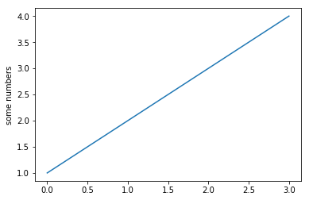

```python
%matplotlib inline
# comando magico do jupyter para visualizações inline
import matplotlib.pyplot as plt # importamos a biblioteca

plt.plot([1,2,3,4]) # da os valores para serem exibidos
plt.ylabel('some numbers') # define a legenda no eixo y
plt.show() # exibe a figura
```

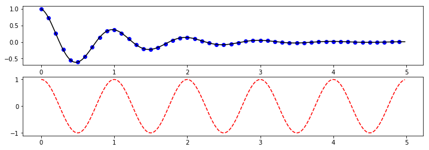

```python
import numpy as np
import matplotlib.pyplot as plt

# define a funçao a ser visualizada
def f(t):
    return np.exp(-t) * np.cos(2*np.pi*t)

# define as variaveis
t1 = np.arange(0.0, 5.0, 0.1)
t2 = np.arange(0.0, 5.0, 0.02)

plt.figure(1, figsize=(12,4)) # define a figura e suas propriedades, como numero e tamanho
plt.subplot(211) # define o subplot
plt.plot(t1, f(t1), 'bo', t2, f(t2), 'k') # define os dadosda figura, tipo de linha, etc

plt.subplot(212)
plt.plot(t2, np.cos(2*np.pi*t2), 'r--')
plt.show() # mostra a figura
```

Outro exemplos podem ser encontrados na [documentação](http://matplotlib.org/index.html) e [galeria](http://matplotlib.org/gallery.html) do Matplotlib.

# Plotando com o Seaborn

O Seaborn é uma camada de alto nível sobre o matplotlib que facilita o trabalho de visualização.

Vamos a alguns exemplos:

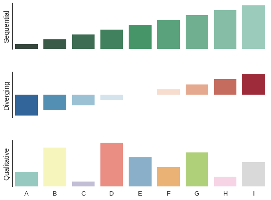

```python
import numpy as np
import seaborn as sns
import matplotlib.pyplot as plt
sns.set(style="white", context="talk")
rs = np.random.RandomState(7)

# Cria e configura a figura
f, (ax1, ax2, ax3) = plt.subplots(3, 1, figsize=(8, 6), sharex=True)

# Gera dados para demonstraçao
x = np.array(list("ABCDEFGHI"))
y1 = np.arange(1, 10)
sns.barplot(x, y1, palette="BuGn_d", ax=ax1)
ax1.set_ylabel("Sequential")

# Trata dados
y2 = y1 - 5
sns.barplot(x, y2, palette="RdBu_r", ax=ax2)
ax2.set_ylabel("Diverging")

# Embaralha dados
y3 = rs.choice(y1, 9, replace=False)
sns.barplot(x, y3, palette="Set3", ax=ax3)
ax3.set_ylabel("Qualitative")

# Mostra a figura
sns.despine(bottom=True)
plt.setp(f.axes, yticks=[])
plt.tight_layout(h_pad=3)
```

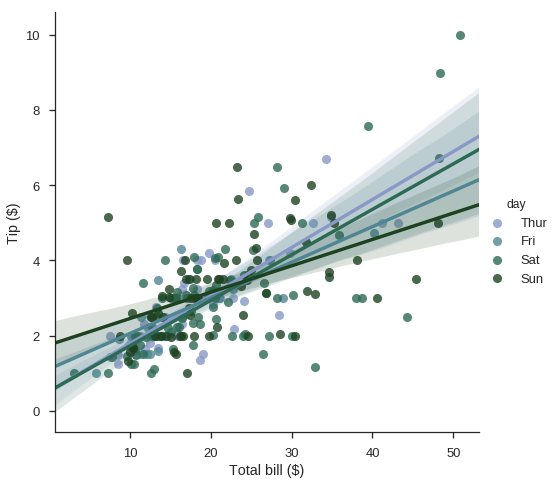

```python
import seaborn as sns
sns.set(style="ticks", context="talk")

# Carrega dados de exemplo
tips = sns.load_dataset("tips")

# Cria uma paleta de cores especial
pal = sns.cubehelix_palette(4, 1.5, .75, light=.6, dark=.2)

# Plota os dados do dataset
g = sns.lmplot(x="total_bill", y="tip", hue="day", data=tips,
               palette=pal, size=7)

# Melhora as legendas
g.set_axis_labels("Total bill ($)", "Tip ($)")
```

Assim como o Matplotlib, o Seaborn tem uma [documentação](https://seaborn.pydata.org/index.html) completa com [galeria de exemplos](https://seaborn.pydata.org/examples/index.html).

# Numpy e Pandas

O [Numpy](http://www.numpy.org/) é a biblioteca matemática padrão do python. Suas rotinas são compiladas em C, Fortran e outras linguagens mais rapidas do que Python, fazendo com que a computação de grande volume de dados seja feita de forma rápida e eficiênte. Sua estrutura de dados básica é o array.

```python
import numpy as np # importa o modulo para uso

array_1 = np.array([i for i in range(1,5)]) # cria o array a partir de uma lista
array_1
```

```
array([1, 2, 3, 4])
```

Um array pode ser modificado em elementos, mas não em tamanho como uma lista. Selecionar elementos por indice também é possivel.

```python
array_1[0] # elemento 0 do array
```

```
1
```

```python
array_1[1] = 5 # modifica o elemento 1 do array para '5'
array_1
```

```
array([1, 5, 3, 4])
```

O numpy realiza operação com seus metodos proprios, como por exemplo:

```python
array_2 = np.multiply(2, array_1) # multiplica um array por um escalar
array_2
```

```
array([ 2, 10,  6,  8])
```

```python
array_3 = np.divide(array_1, array_2) # divide um array pelo outro
array_3
```

```
array([ 0.5,  0.5,  0.5,  0.5])
```

```python
array_4 = np.dot(array_1, array_2.T) # transpoe o array 2 e realiza multiplicaçao matricial (dot)
array_4
```

```
102
```

```python
array_5 = array_3.reshape([-1,2]) # redimensiona o array em uma matriz 2x2
array_5
```

```
array([[ 0.5,  0.5],
       [ 0.5,  0.5]])
```

O Numpy é um modulo muito poderoso e não pretendo demonstrar todas suas funcionalidades aqui. Para maiores informações, recorrer a [documentação](https://docs.scipy.org/doc/numpy/) ou ao seu melhor amigo [Stack Overflow](https://stackoverflow.com/).

O [Pandas](http://pandas.pydata.org/) é o modulo preferido para anáise de dados em Python. Este modulo possui estruturas de dados como o DataFrame, que guarda informações e opera sobre elas de modo extremamente eficiente e intuitivo.

```python
import pandas as pd

df = pd.DataFrame(np.array([np.arange(9), np.arange(9,18)]).T, columns=['column_1', 'column_2'])
df.head()
```

|  | column_1 | column_2 |
| --- | --- | --- |
| 0 | 0 | 9 |
| 1 | 1 | 10 |
| 2 | 2 | 11 |
| 3 | 3 | 12 |
| 4 | 4 | 13 |

O DataFrame possui uma infinidade de métodos úteis, estes podem ser encontrados na [documentação](http://pandas.pydata.org/pandas-docs/stable/generated/pandas.DataFrame.html). Com ele é fácil, por exemplo, selecionar os dados pertencentes a apenas uma coluna, da seguinte forma:

```python
df.column_1.values
```

```
array([0, 1, 2, 3, 4, 5, 6, 7, 8])
```

Operações com os dados também são realizadas de forma facilitada:

```python
df.eval('column_1 * column_2').values
```

```
array([  0,  10,  22,  36,  52,  70,  90, 112, 136], dtype=int64)
```

Outros objetos pythonicos podem ser transformados em DataFrames através dos metodos apropriados, como por exemplo:

```python
dict_df = {'column_1':[1,2,3,4], 'column_2':[5,6,7,8]}
dict_df
```

```
{'column_1': [1, 2, 3, 4], 'column_2': [5, 6, 7, 8]}
```

```python
df_from_dict = pd.DataFrame().from_dict(dict_df)
df_from_dict
```

|  | column_1 | column_2 |
| --- | --- | --- |
| 0 | 1 | 5 |
| 1 | 2 | 6 |
| 2 | 3 | 7 |
| 3 | 4 | 8 |

O pandas também possui a estrutura de dados "Series", que é extremamente útil quando deve-se lidar com dados temporais. A [documentação completa](http://pandas.pydata.org/pandas-docs/stable/api.html) esclarece maiores informações sobre esse modulo tão poderoso. Gaste seu tempo aprendendo a lidar com o pandas, pois ele será um dos seus melhores amigos na hora de fazer análise de dados e resultados.